# Putative Somatic mutation analysis from Monopogen Output

jinzhuang dou@ Kenchen’lab in MDACC

This guide will demonstrate the usage of monopogen output to investigate the clonal lineage. Note, those are only from the putative somatic SNVs in chr20. Users need to merge outputs from 22 chromosomes to obtain the full SNVs list.

#### Step1: Load the output from Monopogen

For the SNV by cell matrix generated from Monopogen, starting from the 19th column, each column denotes on cell with ref/alt format. 0/1: only alternative allele detected; 1/0: only reference allele detected; 1/1: both reference and alternative allele detected

```r
library(Seurat)
library(ggpubr)
meta<- read.csv(file="./chr20.putativeSNVs.csv")
head(meta)
```

```
##     chr    pos Ref_allele Alt_allele Depth_total Depth_ref Depth_alt
## 1 chr20 276310          A          G          10         4         6
## 2 chr20 391901          A          G           2         1         1
## 3 chr20 410498          T          C        1691      1690         1
## 4 chr20 410520          A          T        1980      1978         2
## 5 chr20 436781          A          G          59        51         8
## 6 chr20 438622          T          G          79        63        16
##   SVM_pos_score LDrefine_twoLoci_score LDrefine_trioLoci_score
## 1    0.51311981                     NA                      NA
## 2    0.97847853                     NA                      NA
## 3    0.02451632              0.3448640                      NA
## 4    0.02360158              0.4838710                      NA
## 5    0.02403667              0.4029250               0.1109745
## 6    0.08799017              0.3676751               0.4000000
##   LDrefine_merged_score      BAF_alt
## 1                    NA 0.6000000000
## 2                    NA 0.5000000000
## 3                    NA 0.0005913661
## 4                    NA 0.0010101010
## 5             0.2569497 0.1355932203
## 6             0.3838376 0.2025316456
```

```r
mat <- readRDS(file="./chr20.SNV_mat.RDS")
```

#### Step2: SNV filtering

We only keep putative SNVs with at least 5 wild and 5 mutated alleles supported across all cells

```r
meta_filter <-meta[meta$Depth_ref>5 & meta$Depth_alt>5, ]
```

We then further remove SNVs with at allele frequency of alternative allele larger than 0.5 (they are mostly germline SNVs)

```r
meta_filter <-meta_filter[meta_filter$BAF_alt<0.5, ]
```

We next keep SNVs with LDrefinement score >0.25 to further remove putative germline SNVs

```r
meta_filter <-meta_filter[meta_filter$LDrefine_merged_score>0.25 & !is.na(meta_filter$LDrefine_merged_score), ]
snv_pass <- paste0(meta_filter$chr,":", meta_filter$pos, ":", meta_filter$Ref_allele,":", meta_filter$Alt_allele)
mat <- mat[snv_pass,seq(19,ncol(mat),1)]
colnames(mat) <- paste0(colnames(mat),"-1")
```

#### Step3: Load the seurat object from the RNA data and include the mutation profile in the object

The seurat object (with cell type annotated) could be downloaded from https://drive.google.com/file/d/14Fzeit9H05pGsVEeOKRdqy7HlFFYd6aT/view?usp=drive_link

```r
rna_seurat <- readRDS(file="./BPDCN712_Seurat_Final.rds")

overlap <- intersect(colnames(mat),colnames(rna_seurat))
obj <- subset(rna_seurat,cells=overlap)
mat <- mat[,colnames(obj)]
mat[mat=="0/0"] <- 0
mat[mat=="1/0"] <- (-1)
mat[mat=="0/1"] <- 1
obj[["Geno"]] <- CreateAssayObject(counts = mat)
```

#### Step4: Investigate the mutation distribution among cell types/clusters

```r
enrich_p <- function(sta=NULL){
  if(nrow(sta)==2){
    tol <- rowSums(sta)
    celltype_tol <- colSums(sta)
    rd <-c()
    for(j in seq(1,ncol(sta),1)){
      if(sum(sta[,j])>2){
        data <-rbind(sta[,j], tol-sta[,j])
        res <-  fisher.test(data)
        rd <-rbind(rd, c(colnames(sta)[j] , res$p.value))
      }
    }
    rd <- data.frame("celltype"=as.character(rd[,1]),"pval"=as.numeric(rd[,2]))
  }
  else{
    return(NULL)
  }
}

res <- c()
for(i in seq(1,nrow(mat),1)){
   snv_profile <- data.frame("SNV"=as.vector(obj[["Geno"]][i,]), "Celltype"=obj@meta.data$CellType)
   sta <- table(snv_profile)
   sta <- sta[c("-1","1"),]
   out <- enrich_p(sta=sta)
   if(!is.null(out)){
     min_pval <- as.vector(out[out$pval==min(out$pval),])
     res <- rbind(res, c(rownames(mat)[i], as.character(min_pval[1,1]), min_pval[1,2]))
   }
}
res <- data.frame("SNV"=res[,1], "celltype"=res[,2],"pval"=as.numeric(res[,3]))
res <- res[order(res$pval),]
head(res)
```

```
##                    SNV celltype        pval
## 27   chr20:3933453:T:C      CTL 0.001876335
## 51  chr20:18143827:T:C        T 0.012405454
## 45  chr20:13609374:A:G        T 0.016275489
## 106 chr20:37083536:T:C        T 0.018387902
## 57  chr20:20047764:T:A      CTL 0.020979021
## 58  chr20:21115066:C:A        T 0.030801836
```

#### Show the mutation profiles from first example chr20:3933453:T:C

```r
SNV_ex <- "chr20:3933453:T:C"
obj@meta.data$Mutec <- as.vector( obj[["Geno"]][SNV_ex,])
cell_ref <- colnames(obj)[obj@meta.data$Mutec%in%c(-1)]
cell_alt <- colnames(obj)[obj@meta.data$Mutec%in%c(1)]
p1 <- DimPlot(obj,group.by = "CellType", pt.size=2, label=T) + NoLegend()
p2 <- DimPlot(obj ,cells.highlight = list("Ref"= cell_ref, "Alt"= cell_alt),  cols.highlight = c( "blue",  "red"), cols="gray", pt.size=2, sizes.highlight = 2, main=SNV_ex)
```

```
## The following functions and any applicable methods accept the dots: CombinePlots
```

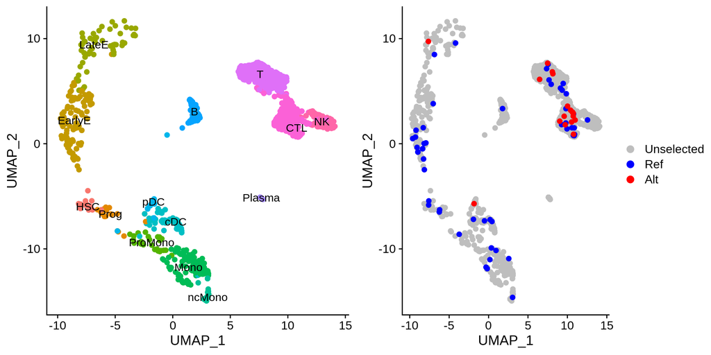

```r
p <- ggarrange(p1,p2)
p
```

#### Show the mutation profiles from the second example chr20:18143827:T:C

```r
SNV_ex <- "chr20:18143827:T:C"
obj@meta.data$Mutec <- as.vector( obj[["Geno"]][SNV_ex,])
cell_ref <- colnames(obj)[obj@meta.data$Mutec%in%c(-1)]
cell_alt <- colnames(obj)[obj@meta.data$Mutec%in%c(1)]
p1 <- DimPlot(obj,group.by = "CellType", pt.size=2, label=T) + NoLegend()
p2 <- DimPlot(obj ,cells.highlight = list("Ref"= cell_ref, "Alt"= cell_alt),  cols.highlight = c( "blue",  "red"), cols="gray", pt.size=2, sizes.highlight = 2, main=SNV_ex)
```

```
## The following functions and any applicable methods accept the dots: CombinePlots
```

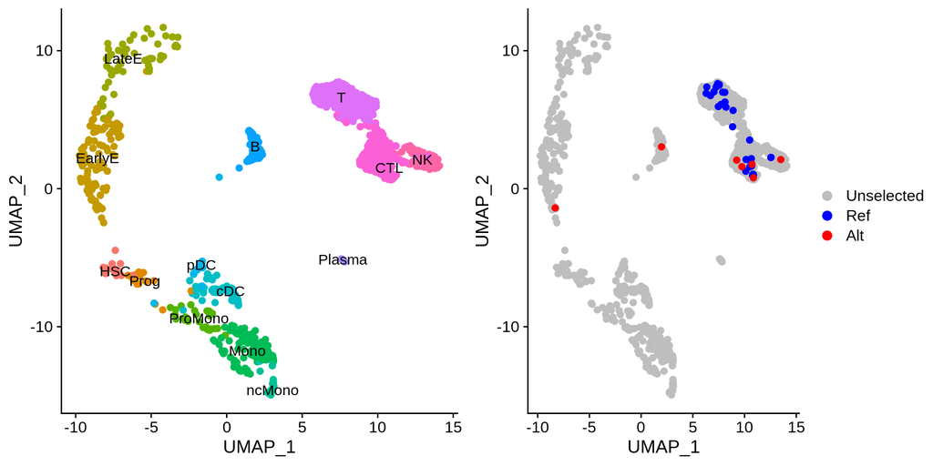

```r
p <- ggarrange(p1,p2)
p
```

#### Show the mutation profiles from the third example chr20:13609374:A:G

```r
SNV_ex <- "chr20:13609374:A:G"
obj@meta.data$Mutec <- as.vector( obj[["Geno"]][SNV_ex,])
cell_ref <- colnames(obj)[obj@meta.data$Mutec%in%c(-1)]
cell_alt <- colnames(obj)[obj@meta.data$Mutec%in%c(1)]
p1 <- DimPlot(obj,group.by = "CellType", pt.size=2, label=T) + NoLegend()
p2 <- DimPlot(obj ,cells.highlight = list("Ref"= cell_ref, "Alt"= cell_alt),  cols.highlight = c( "blue",  "red"), cols="gray", pt.size=2, sizes.highlight = 2, main=SNV_ex)
```

```
## The following functions and any applicable methods accept the dots: CombinePlots
```

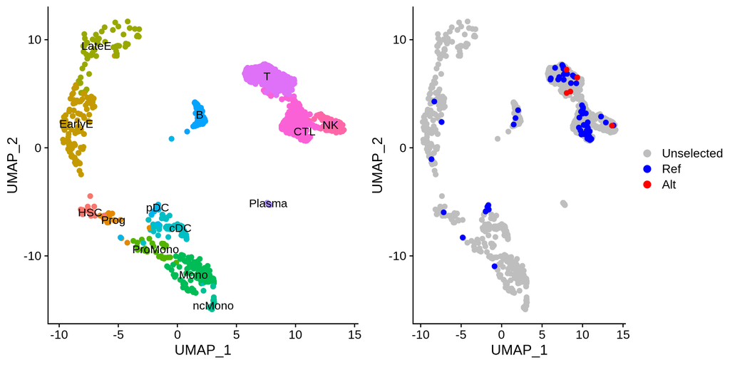

```r
p <- ggarrange(p1,p2)
p
```

Given the lack of ground truth for putative somatic SNVs validtion, users can select putative somatic SNVs based on additional evidences.